# DA101 - Final project assignment

Wilson Le

10/21/2020

# THE EFFECTS OF CLIMATE ON THE SPREAD OF COVID-19

## Introduction:

Corona virus disease 2019 (COVID-19), initially identified in December 2019 in Wuhan, China, has now become a global pandemic. It is a very infectious virus that spreads between humans, mainly via physical contact with bodily fluids[1]. Scientific research has shown that climate temperature plays a role in the spreading of the virus[2]. This research aim to redo the experiment using different data and techniques to see if the claims made in the researches are true.

## Ethical Considerations:

Since the researching the research is using data from the internet for analysis, the data itself are public for every one to look at and process. However, the research is conducted by an individual (me), however carefully conducted, there will be flaws and mistakes in logic and assumptions. There are potential for harm in this analysis. As Covid19 is a very unpredictable infectious disease, these analysis should only be part of the consideration of your decision to act upon the disease.

## Data processing

Import libraries

```r
library(tidyverse)
library(knitr)
library(GGally)
library(stringi)
```

Import data:

```r
Covid19Data <- read.csv('Covid-19-All-State-History.csv')
maxTempData <- read.csv('./csv/tMax_US.csv')
minTempData <- read.csv('./csv/tMin_US.csv')
windData <- read.csv('./csv/wind_US.csv')
stateData <- read.csv('./csv/states.csv')
```

Process Covid19 data:

```r
Covid19Data <- Covid19Data %>%

  # Select the wanted variables:
  select(date, state, positiveCasesViral, totalTestsPeopleViral) %>%

  # Remove incomplete observations:
  na.omit()

# Aggregate monthly sum positive case of each state:
SumPositiveCase <- aggregate(Covid19Data$positiveCasesViral, by=list(state=Covid19Data$state, date = Covid19Data$date), FUN=sum) %>% rename(positiveCaseViral = x)

# Aggregate monthly sum tests of each state:
SumTests <- aggregate(Covid19Data$totalTestsPeopleViral, by=list(state=Covid19Data$state, date = Covid19Data$date), FUN=sum) %>% rename(totalTestsPeopleViral = x)

# Merge the two together:
Covid19SumData <- merge(SumPositiveCase, SumTests, by=c("state", "date"))


kable(head(Covid19SumData, n=20))
```

| state | date | positiveCaseViral | totalTestsPeopleViral |
| --- | --- | --- | --- |
| AZ | 2020-06-11 | 30955 | 309273 |
| AZ | 2020-06-12 | 30955 | 320816 |
| AZ | 2020-06-13 | 34146 | 328085 |
| AZ | 2020-06-14 | 35374 | 337728 |
| AZ | 2020-06-15 | 36377 | 344929 |
| AZ | 2020-06-16 | 38754 | 353991 |
| AZ | 2020-06-17 | 40577 | 365846 |
| AZ | 2020-06-18 | 43085 | 379374 |
| AZ | 2020-06-19 | 46323 | 391850 |
| AZ | 2020-06-20 | 49426 | 404908 |
| AZ | 2020-06-21 | 52018 | 419372 |
| AZ | 2020-06-22 | 54214 | 429418 |
| AZ | 2020-06-23 | 57799 | 440138 |
| AZ | 2020-06-24 | 59586 | 448800 |
| AZ | 2020-06-25 | 62634 | 463800 |
| AZ | 2020-06-26 | 66055 | 479330 |
| AZ | 2020-06-27 | 69641 | 494337 |
| AZ | 2020-06-28 | 73497 | 509485 |
| AZ | 2020-06-29 | 74119 | 511009 |
| AZ | 2020-06-30 | 78781 | 531922 |

Process max temperature data:

```r
# Calculate the mean maximum daily temperature.
maxTempbyProv <- aggregate(maxTempData[12:269] , by=list(province=maxTempData$Province_State), FUN=mean)


# Select just the state and the mean maximum daily temperature of states.
maxTempbyProv <- maxTempbyProv %>% select(province, starts_with("X"))

# Define function to transpose a state's daily temperature data.
transposeMaxState <- function(stateName){
  df <- maxTempbyProv %>% filter(province == as.character(stateName)) %>%
    select(starts_with("X")) %>%
    t() %>%
    as.data.frame()
  df <- df %>%
    mutate(unformatedDate = substr(rownames(df), start=2, stop=8)) %>%
    mutate(province = stateName) %>% rename(Max = V1) %>%
    mutate(date = as.Date.character(unformatedDate, format="%m.%d.%y")) %>%
    select(!unformatedDate)
  return(df)
}

# Define function to bind all the transposed data.
bindStates <- function(){
  bindDf <- data.frame()
  for (state in maxTempbyProv$province){
    tempDf <- transposeMaxState(state)
    bindDf <- rbind(bindDf, tempDf)
  }
  return(bindDf)
}

# Transposed maximum temperature data
maxTempbyProvTransposed <- bindStates()

#Display the first 10 value of the new data set.
kable(head(maxTempbyProvTransposed, n=20))
```

| Max | province | date |
| --- | --- | --- |
| 14.462687 | Alabama | 2020-01-01 |
| 15.328358 | Alabama | 2020-01-02 |
| 17.014925 | Alabama | 2020-01-03 |
| 17.850746 | Alabama | 2020-01-04 |
| 13.194030 | Alabama | 2020-01-05 |
| 14.283582 | Alabama | 2020-01-06 |
| 17.910448 | Alabama | 2020-01-07 |
| 15.343284 | Alabama | 2020-01-08 |
| 16.582090 | Alabama | 2020-01-09 |
| 18.791045 | Alabama | 2020-01-10 |
| 21.850746 | Alabama | 2020-01-11 |
| 22.194030 | Alabama | 2020-01-12 |
| 18.194030 | Alabama | 2020-01-13 |
| 20.059701 | Alabama | 2020-01-14 |
| 20.298507 | Alabama | 2020-01-15 |
| 21.776119 | Alabama | 2020-01-16 |
| 18.567164 | Alabama | 2020-01-17 |
| 18.328358 | Alabama | 2020-01-18 |
| 16.507463 | Alabama | 2020-01-19 |
| 9.955224 | Alabama | 2020-01-20 |

Process min temperature data:

```r
#Calculate the mean minimum daily temperature of a state.
minTempbyProv <- aggregate(minTempData[12:269] , by=list(province=minTempData$Province_State), FUN=mean)

# Select just the state and the mean maximum daily temperature of states.
minTempbyProv <- minTempbyProv %>% select(province, starts_with("X"))

# Define function to transpose a state's temperature per month data.
transposeMinState <- function(stateName){
  df <- minTempbyProv %>% filter(province == as.character(stateName)) %>%
    select(starts_with("X")) %>%
    t() %>%
    as.data.frame()
  df <- df %>%
    mutate(unformatedDate = substr(rownames(df), start=2, stop=8)) %>%
    mutate(province = stateName) %>% rename(Min = V1) %>%
    mutate(date = as.Date.character(unformatedDate, format="%m.%d.%y")) %>%
    select(!unformatedDate)
  return(df)
}

# Define function to bind all the transposed data.
bindStates <- function(){
  bindDf <- data.frame()
  for (state in minTempbyProv$province){
    tempDf <- transposeMinState(state)
    bindDf <- rbind(bindDf, tempDf)
  }
  return(bindDf)
}

# Transposed maximum temperature data
minTempbyProvTransposed <- bindStates()

#Display the first 10 value of the new data set.
kable(head(minTempbyProvTransposed, n=20))
```

| Min | province | date |
| --- | --- | --- |
| 0.6119403 | Alabama | 2020-01-01 |
| 8.0447761 | Alabama | 2020-01-02 |
| 14.5522388 | Alabama | 2020-01-03 |
| 10.0895522 | Alabama | 2020-01-04 |
| -0.1194030 | Alabama | 2020-01-05 |
| 2.1641791 | Alabama | 2020-01-06 |
| 7.4029851 | Alabama | 2020-01-07 |
| 0.3880597 | Alabama | 2020-01-08 |
| 2.0447761 | Alabama | 2020-01-09 |
| 12.9253731 | Alabama | 2020-01-10 |
| 17.4179104 | Alabama | 2020-01-11 |
| 8.5373134 | Alabama | 2020-01-12 |
| 12.4776119 | Alabama | 2020-01-13 |
| 16.6417910 | Alabama | 2020-01-14 |
| 14.8805970 | Alabama | 2020-01-15 |
| 14.2686567 | Alabama | 2020-01-16 |
| 6.7761194 | Alabama | 2020-01-17 |
| 9.0597015 | Alabama | 2020-01-18 |
| 3.6119403 | Alabama | 2020-01-19 |
| -2.0149254 | Alabama | 2020-01-20 |

Process wind data:

```r
#Filter out invalid values:
windDataFiltered <- windData %>% filter_at(vars(starts_with("X")), all_vars(. > 0))

#Calculate the mean minimum daily wind speed of a state.
windByProv <- aggregate(windDataFiltered[12:269] , by=list(province=windDataFiltered$Province_State), FUN=mean)

# Select just the state and the mean maximum daily wind speed of states.
windByProv <- windByProv %>% select(province, starts_with("X"))

# Define function to transpose a state's temperature per month data.
transposeWinState <- function(stateName){
  df <- windByProv %>% filter(province == as.character(stateName)) %>%
    select(starts_with("X")) %>%
    t() %>%
    as.data.frame()
  df <- df %>%
    mutate(unformatedDate = substr(rownames(df), start=2, stop=8)) %>%
    mutate(province = stateName) %>% rename(Wind = V1) %>%
    mutate(date = as.Date.character(unformatedDate, format="%m.%d.%y")) %>%
    select(!unformatedDate)
  return(df)
}

# Define function to bind all the transposed data.
bindStates <- function(){
  bindDf <- data.frame()
  for (state in windByProv$province){
    tempDf <- transposeWinState(state)
    bindDf <- rbind(bindDf, tempDf)
  }
  return(bindDf)
}

# Transposed maximum temperature data
windByProvTransposed <- bindStates()

#Display the first 10 value of the new data set.
kable(head(windByProvTransposed, n=20))
```

| Wind | province | date |
| --- | --- | --- |
| 2.000000 | Alabama | 2020-01-01 |
| 1.000000 | Alabama | 2020-01-02 |
| 4.000000 | Alabama | 2020-01-03 |
| 2.000000 | Alabama | 2020-01-04 |
| 3.333333 | Alabama | 2020-01-05 |
| 1.333333 | Alabama | 2020-01-06 |
| 1.333333 | Alabama | 2020-01-07 |
| 3.333333 | Alabama | 2020-01-08 |
| 1.000000 | Alabama | 2020-01-09 |
| 3.333333 | Alabama | 2020-01-10 |
| 4.666667 | Alabama | 2020-01-11 |
| 5.333333 | Alabama | 2020-01-12 |
| 1.000000 | Alabama | 2020-01-13 |
| 1.000000 | Alabama | 2020-01-14 |
| 2.000000 | Alabama | 2020-01-15 |
| 1.333333 | Alabama | 2020-01-16 |
| 2.666667 | Alabama | 2020-01-17 |
| 3.333333 | Alabama | 2020-01-18 |
| 3.666667 | Alabama | 2020-01-19 |
| 4.666667 | Alabama | 2020-01-20 |

Merge temperature and wind data:

```r
# Merge the max and min temperature into one data set.
TempByProv <- merge(maxTempbyProvTransposed, minTempbyProvTransposed, by = c("province", "date"))
ClimateByProv <- merge(TempByProv, windByProvTransposed, by = c("province", "date"))
# Display the first 10 values of the merged temperature data set.
options(digits = 3)
kable(head(ClimateByProv, n = 10))
```

| province | date | Max | Min | Wind |
| --- | --- | --- | --- | --- |
| Alabama | 2020-01-01 | 14.5 | 0.612 | 2.00 |
| Alabama | 2020-01-02 | 15.3 | 8.045 | 1.00 |
| Alabama | 2020-01-03 | 17.0 | 14.552 | 4.00 |
| Alabama | 2020-01-04 | 17.9 | 10.090 | 2.00 |
| Alabama | 2020-01-05 | 13.2 | -0.119 | 3.33 |
| Alabama | 2020-01-06 | 14.3 | 2.164 | 1.33 |
| Alabama | 2020-01-07 | 17.9 | 7.403 | 1.33 |
| Alabama | 2020-01-08 | 15.3 | 0.388 | 3.33 |
| Alabama | 2020-01-09 | 16.6 | 2.045 | 1.00 |
| Alabama | 2020-01-10 | 18.8 | 12.925 | 3.33 |

Merge temperature data with Covid19 data:

```r
ClimateByState <- merge(ClimateByProv, stateData, by=c("province"))
Covid19Climate <- merge(ClimateByState, Covid19SumData, by=c("state", "date"))

# Display the first 10 values of the merged temperature data set.
options(digits = 3)
kable(head(Covid19Climate, n = 10))
```

| state | date | province | Max | Min | Wind | positiveCaseViral | totalTestsPeopleViral |
| --- | --- | --- | --- | --- | --- | --- | --- |
| AZ | 2020-06-11 | Arizona | 33.5 | 15.8 | 1.93 | 30955 | 309273 |
| AZ | 2020-06-12 | Arizona | 36.2 | 17.9 | 2.67 | 30955 | 320816 |
| AZ | 2020-06-13 | Arizona | 35.9 | 18.1 | 3.60 | 34146 | 328085 |
| AZ | 2020-06-14 | Arizona | 33.7 | 15.5 | 4.40 | 35374 | 337728 |
| AZ | 2020-06-15 | Arizona | 33.7 | 15.7 | 3.27 | 36377 | 344929 |
| AZ | 2020-06-16 | Arizona | 34.3 | 17.3 | 3.07 | 38754 | 353991 |
| AZ | 2020-06-17 | Arizona | 33.8 | 16.7 | 4.13 | 40577 | 365846 |
| AZ | 2020-06-18 | Arizona | 33.6 | 15.3 | 3.87 | 43085 | 379374 |
| AZ | 2020-06-19 | Arizona | 33.2 | 15.4 | 2.80 | 46323 | 391850 |
| AZ | 2020-06-20 | Arizona | 33.4 | 16.3 | 2.27 | 49426 | 404908 |

## Data Explanation and Exploration:

As stated above, the research will be looking at the spread of Covid-19, which is determined by the number of confirmed positive test cases in the states. The variables that might affect the spread are the temperature of the states.

The dependent variable will be taken from the COVID tracking project’s data set. The project is a non-profit organization tasked to collect and publish data required to quantify the spread and seriousness of COVID-19 in the United States. The data is now being collected by volunteers and processed and analyzed by developers, scientists, designers, editors, reporters, and many enthusiast contributors[5]. Despite being collected by volunteers, there are strict quality scoring methods in place for all these collected data. This project has been collecting data since January of 2020. With the vast amount of data and its precision, this data set samples the real situation of any collected regions. There are many variables in this data set, but this research only pays attention to a few of them. The “date” and “state” are 2 necessary variables to tell when and where the data is collected, along with the number that we are looking for, the “positiveCasesViral” and “totalTestsPeopleViral”. According to the metadata provided by the data owners, the variable “positiveCasesViral” corresponds to “the total number of unique people with a complete PCR test that returns positive”, or in other words, the total of confirmed cases, and the variable “totalTestsPeopleViral” corresponds to the total number of “unique people tested at least once via PCR testings”[6]. These 4 variables from this data set will provide data of confirmed cases in each state over a time period, which consequently corresponds to the spread of the pandemic in state areas of the whole country.

Moving on to the two independent variables, the data set collected by Eeemonts on Kaggle will provide precise data. This data set is actually compiled by calling API requests from Dark Sky, a company that’s recently acquired by Apple but the API data collection is still available. This company measures weather information and updates it by the minute[7]. Eeemonts has been pulling and compiling data since January 2020, resulting in a massive cluster of data sets that includes a multitude of variables[5]. The sample that this cluster of data sets is a detailed data weather information of every city of state every day since January. However, we are only paying attention to two data sets, the “tMax_US.csv” and “tMin_US.csv”. These data sets include two important variables that the research needs: the maximum temperature and the minimum temperature of a city in a state in a day, which, will provide the range of temperature of a state.

The challenge is that these two data set are formatted differently, so data wrangling is a challenge step, in order to produce a neat and usable data set for analysis. The Covid19 Data has more rows than columns, as the “Date” and “State” variable has its own column, meaning that for the number of rows will be the product of the number of states and the number of dates, resulting in more rows than columns. As for the temperature data set, there is more columns than rows. This is because instead of having a column specifically for dates, the data set is formatted so that every day has its own columns, and the intersection between the date and the state will be the temperature value. This means that the number of rows will be equal to the number of states, but the number of columns will be as many as the number of days, resulting in a data that has more columns than rows. To deal with this is a challange, as I have to transpose the temperature data and wrote my own function to turn it into the same format as the Covid-19 data. Only then can I merge the two data set together and start with my data exploration and analysis.

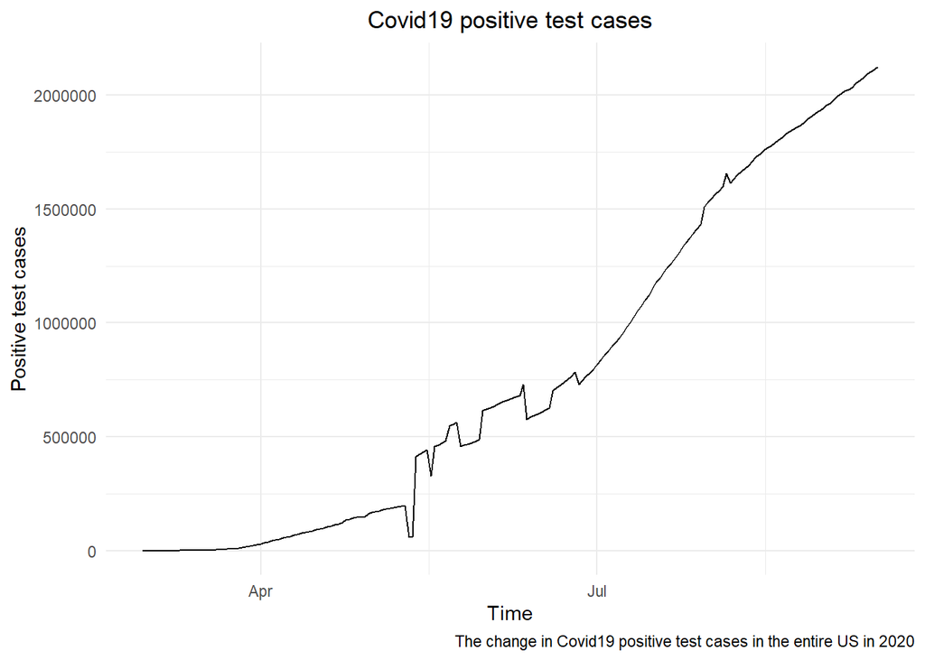

```r
#Aggregate monthly sum test of entire US:
Covid19SumPos <- aggregate(Covid19Climate$positiveCaseViral, by=list(date = Covid19Climate$date), FUN=sum) %>% rename(positiveCaseViral = x)

#Plot
ggplot(Covid19SumPos, aes(date, positiveCaseViral)) +
  geom_line() +
  labs(
    title="Covid19 positive test cases",
    caption='The change in Covid19 positive test cases in the entire US in 2020',
    x="Time",
    y="Positive test cases") +
  theme_minimal() +
  theme(plot.title = element_text(hjust = 0.5))
```

Frequency polygon showing distribution of maximum and minimum temperature across all the states:

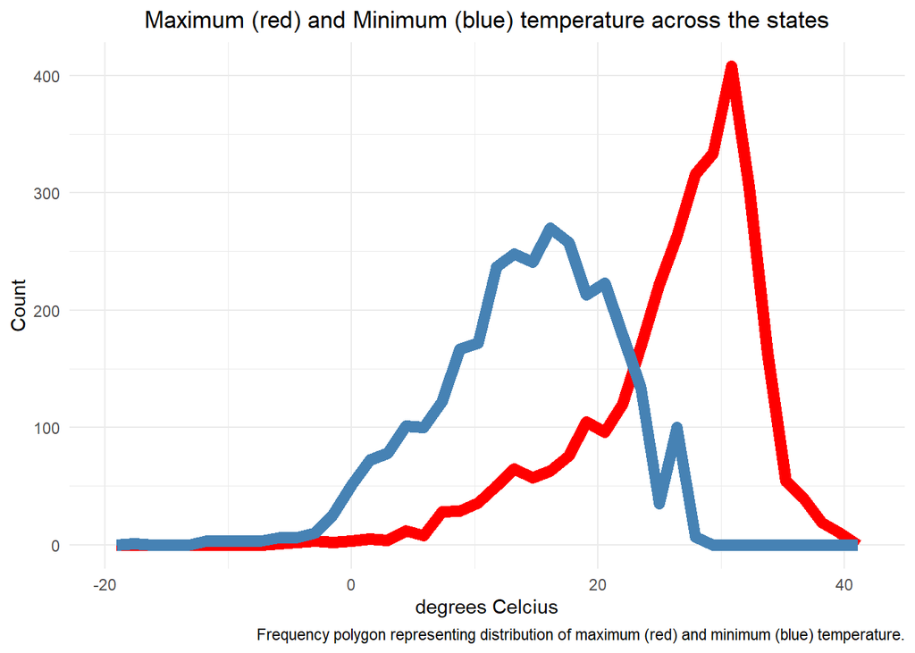

```r
ggplot(Covid19Climate) +
  geom_freqpoly(bins = 40, aes(Max), color="red", size=3) +
  geom_freqpoly(bins = 40, aes(Min), color="steelblue", size=3) +
  labs(title="Maximum (red) and Minimum (blue) temperature across the states",
    caption="Frequency polygon representing distribution of maximum (red) and minimum (blue) temperature.",
    x="degrees Celcius",
    y="Count") +
  theme_minimal() +
  theme(plot.title = element_text(hjust = 0.5))
```

Line plot showing changes in maximum and minimum temperature across the months:

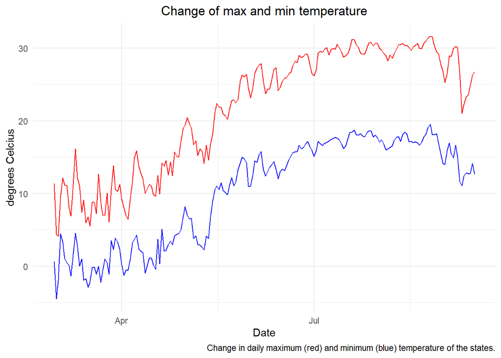

```r
#Calculate daily mean maximum temperature across all state.
Covid19MaxTemp <- aggregate(Covid19Climate$Max, by=list(date=Covid19Climate$date), FUN=mean) %>%
  rename(Max = x)

#Calculate daily mean minimum temperature across all state.
Covid19MinTemp <- aggregate(Covid19Climate$Min, by=list(date=Covid19Climate$date), FUN=mean) %>%
  rename(Min = x)

#Merge the two to create a data frame of daily mean minimum, maximum temperaturea across all states.
Covid19DailyTemp <- merge(Covid19MaxTemp, Covid19MinTemp, by="date")

ggplot(Covid19DailyTemp) +
  geom_line(aes(date, Max), color="red") +
  geom_line(aes(date, Min), color="blue") +
  labs(
    title="Change of max and min temperature",
    caption="Change in daily maximum (red) and minimum (blue) temperature of the states.",
    x="Date",
    y="degrees Celcius") +
  theme_minimal() +
  theme(plot.title = element_text(hjust = 0.5))
```

Checking for multicolinearity between min, max temperature, and wind speed:

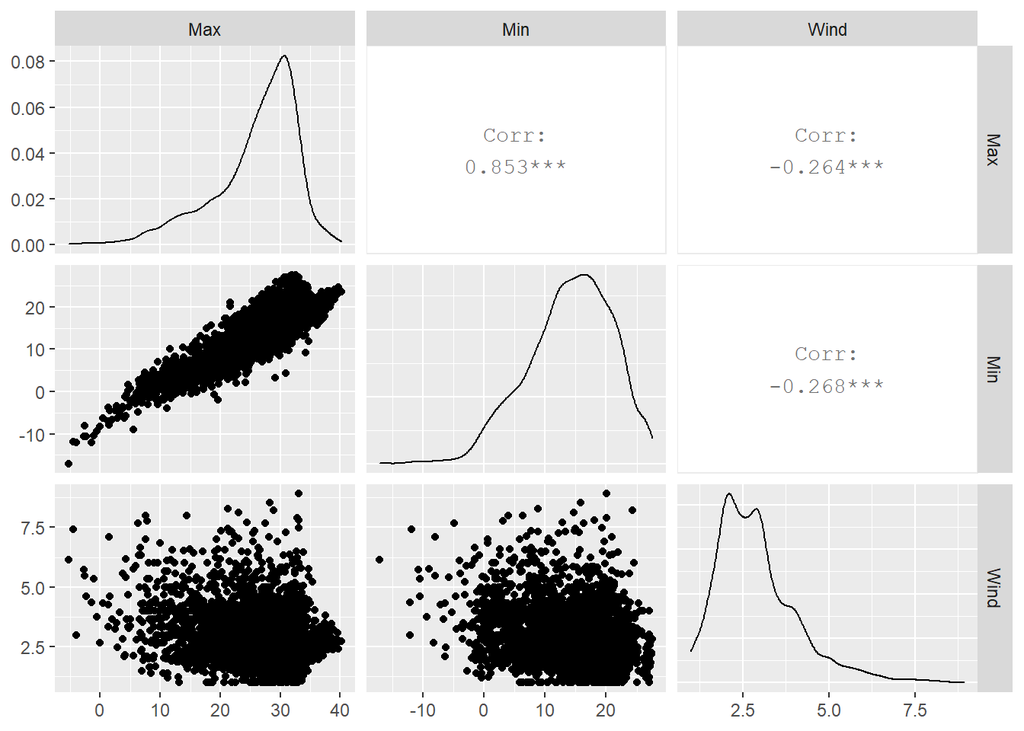

```r
ggpairs(Covid19Climate, columns=c("Max", "Min", "Wind"))
```

## Statistical Analysis and Interpretation:

Test for correlation between daily wind speed, minimum, maximum temperature and the number of positive test case.

```r
cor.test(Covid19Climate$Min, Covid19Climate$positiveCaseViral, method = "pearson")
```

```
##
##  Pearson's product-moment correlation
##
## data:  Covid19Climate$Min and Covid19Climate$positiveCaseViral
## t = 20, df = 3067, p-value <2e-16
## alternative hypothesis: true correlation is not equal to 0
## 95 percent confidence interval:
##  0.315 0.377
## sample estimates:
##   cor
## 0.346
```

```r
cor.test(Covid19Climate$Max, Covid19Climate$positiveCaseViral, method = "pearson")
```

```
##
##  Pearson's product-moment correlation
##
## data:  Covid19Climate$Max and Covid19Climate$positiveCaseViral
## t = 16, df = 3067, p-value <2e-16
## alternative hypothesis: true correlation is not equal to 0
## 95 percent confidence interval:
##  0.251 0.316
## sample estimates:
##   cor
## 0.284
```

```r
cor.test(Covid19Climate$Wind, Covid19Climate$positiveCaseViral, method = "pearson")
```

```
##
##  Pearson's product-moment correlation
##
## data:  Covid19Climate$Wind and Covid19Climate$positiveCaseViral
## t = -7, df = 3067, p-value = 6e-12
## alternative hypothesis: true correlation is not equal to 0
## 95 percent confidence interval:
##  -0.1584 -0.0887
## sample estimates:
##    cor
## -0.124
```

```r
train_test <- split(Covid19Climate, sample(0:107, size=2, replace=F))
test <- as.data.frame(train_test[2])
train <- as.data.frame(train_test[1])
colnames(test) <- colnames(Covid19Climate)
colnames(train) <- colnames(Covid19Climate)

maxTempModel <- lm(positiveCaseViral ~ Max, data=Covid19Climate)
minTempModel <- lm(positiveCaseViral ~ Min, data=Covid19Climate)
WindModel <- lm(positiveCaseViral ~ Wind, data=Covid19Climate)

summary(maxTempModel)
```

```
##
## Call:
## lm(formula = positiveCaseViral ~ Max, data = Covid19Climate)
##
## Residuals:
##    Min     1Q Median     3Q    Max
## -75730 -39970 -18253  13158 591593
##
## Coefficients:
##             Estimate Std. Error t value Pr(>|t|)
## (Intercept)   -37534       5560   -6.75  1.8e-11 ***
## Max             3390        207   16.40  < 2e-16 ***
## ---
## Signif. codes:  0 '***' 0.001 '**' 0.01 '*' 0.05 '.' 0.1 ' ' 1
##
## Residual standard error: 80200 on 3067 degrees of freedom
## Multiple R-squared:  0.0806, Adjusted R-squared:  0.0803
## F-statistic:  269 on 1 and 3067 DF,  p-value: <2e-16
```

```r
summary(minTempModel)
```

```
##
## Call:
## lm(formula = positiveCaseViral ~ Min, data = Covid19Climate)
##
## Residuals:
##     Min      1Q  Median      3Q     Max
## -106542  -37126  -12016   14687  564753
##
## Coefficients:
##             Estimate Std. Error t value Pr(>|t|)
## (Intercept)    -8599       3222   -2.67   0.0077 **
## Min             4201        206   20.43   <2e-16 ***
## ---
## Signif. codes:  0 '***' 0.001 '**' 0.01 '*' 0.05 '.' 0.1 ' ' 1
##
## Residual standard error: 78500 on 3067 degrees of freedom
## Multiple R-squared:  0.12,   Adjusted R-squared:  0.119
## F-statistic:  417 on 1 and 3067 DF,  p-value: <2e-16
```

```r
summary(WindModel)
```

```
##
## Call:
## lm(formula = positiveCaseViral ~ Wind, data = Covid19Climate)
##
## Residuals:
##    Min     1Q Median     3Q    Max
## -66805 -41083 -23969  12678 614049
##
## Coefficients:
##             Estimate Std. Error t value Pr(>|t|)
## (Intercept)    75895       3968   19.13  < 2e-16 ***
## Wind           -8749       1267   -6.91  6.1e-12 ***
## ---
## Signif. codes:  0 '***' 0.001 '**' 0.01 '*' 0.05 '.' 0.1 ' ' 1
##
## Residual standard error: 83000 on 3067 degrees of freedom
## Multiple R-squared:  0.0153, Adjusted R-squared:  0.015
## F-statistic: 47.7 on 1 and 3067 DF,  p-value: 6.07e-12
```

The stars (***) are the significance level, computed and displayed based on the p-value of the model. Based on the summary, we can see that all three models level 2 or 3 significance, indicating that it’s unlikely that no relationship exist between the number of positive test cases and climate values (minimum temperature, maximum temperature, wind speed).

The F-value in these models are the results of tests where the null hypothesis is “all of the regression coefficients are equal to zero”. Since the p-value of all 3 models are much less than the alpha level, the null hypothesis can be rejected. All the models have their F-statistic relatively larger than 1, given the size of the data, insinuating that there may be correlations between the independent variables and the number of positive test cases in the US.

```r
test <- test %>%
  mutate(predictionWindDiff =  abs(positiveCaseViral - predict(WindModel, test))) %>%
  mutate(predictionMinDiff =  abs(positiveCaseViral - predict(minTempModel, test))) %>%
  mutate(predictionMaxDiff =  abs(positiveCaseViral - predict(maxTempModel, test)))
```

Histograms representing difference between predicted number of positive cases and actual positive cases:

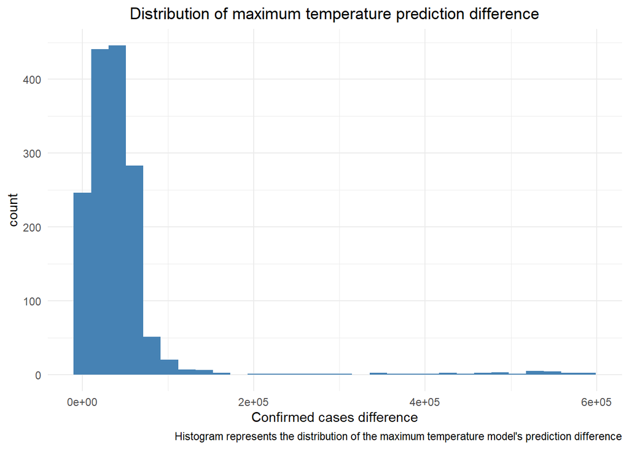

```r
ggplot(test, aes(test$predictionMaxDiff)) +
  geom_histogram(fill="steelblue") +
  labs(
    title="Distribution of maximum temperature prediction difference",
    caption="Histogram represents the distribution of the maximum temperature model's prediction difference",
    x="Confirmed cases difference") +
  theme_minimal() +
  theme(plot.title = element_text(hjust = 0.5))
```

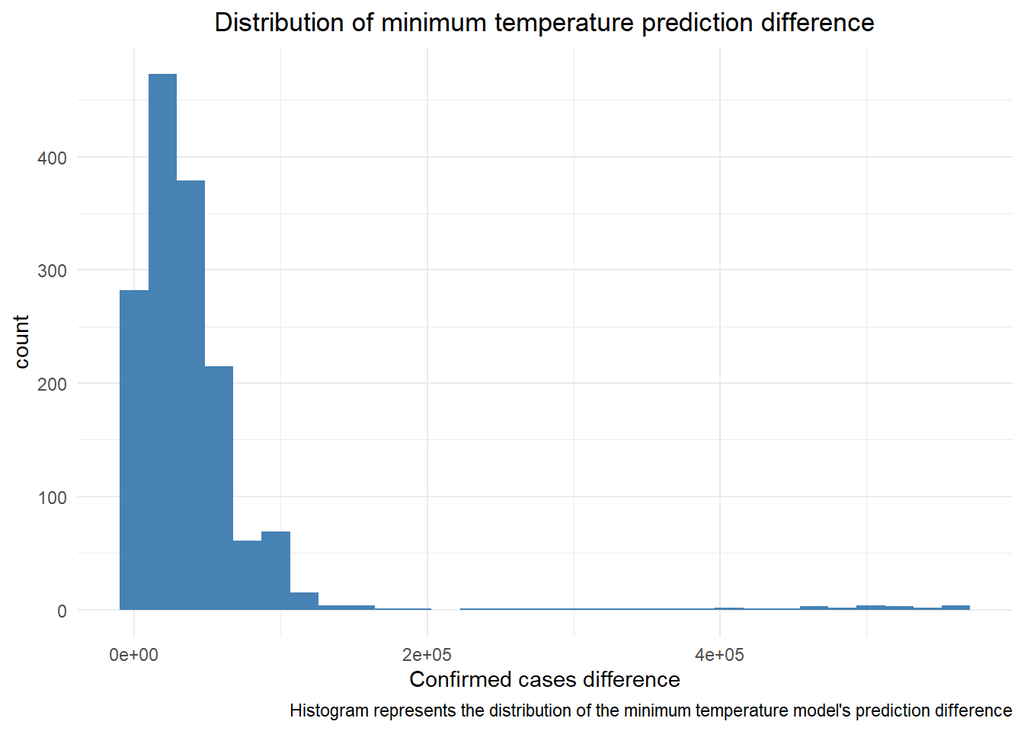

```r
ggplot(test, aes(test$predictionMinDiff)) +
  geom_histogram(fill="steelblue") +
  labs(
    title="Distribution of minimum temperature prediction difference",
    caption="Histogram represents the distribution of the minimum temperature model's prediction difference",
    x="Confirmed cases difference") +
  theme_minimal() +
  theme(plot.title = element_text(hjust = 0.5))
```

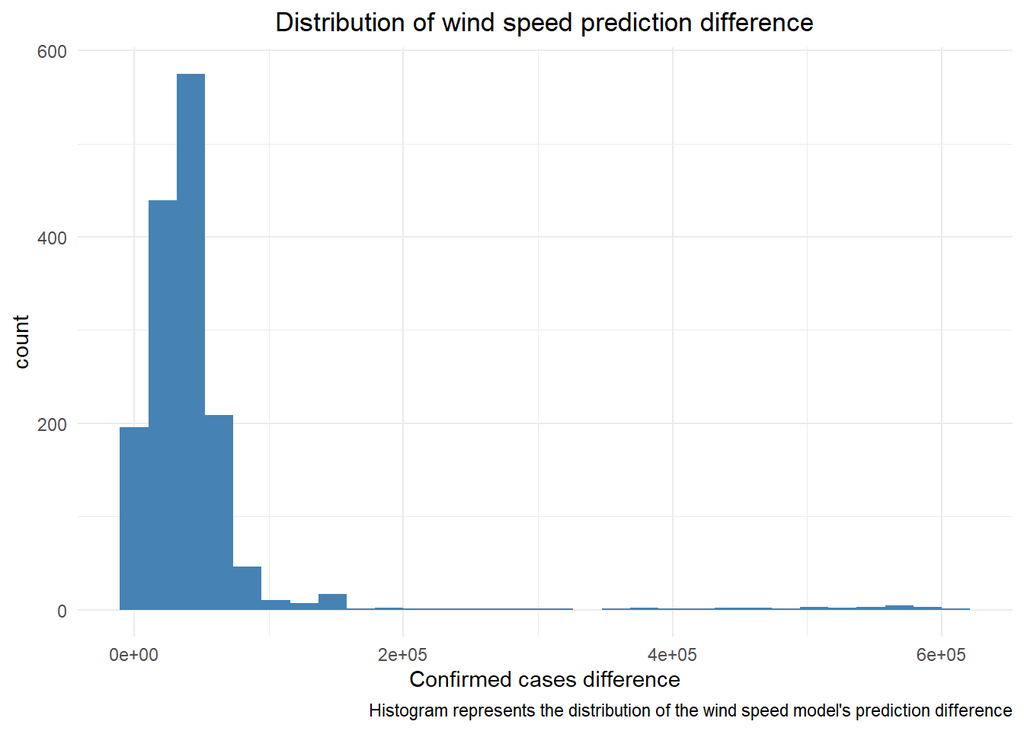

```r
ggplot(test, aes(test$predictionWindDiff)) +
  geom_histogram(fill="steelblue") +
  labs(
    title="Distribution of wind speed prediction difference",
    caption="Histogram represents the distribution of the wind speed model's prediction difference",
    x="Confirmed cases difference") +
  theme_minimal() +
  theme(plot.title = element_text(hjust = 0.5))
```

## Conclusions:

Reference that is relevant and supports my insights[8]:

Xie, Jingui, and Yongjian Zhu. “Association between Ambient Temperature and COVID-19 Infection in 122 Cities from China.” Science of The Total Environment, Elsevier, 30 Mar. 2020, www.sciencedirect.com/science/article/pii/S0048969720317149

## Works Cited:

> 1. “How Coronavirus Spreads.” Centers for Disease Control and Prevention, Centers for Disease Control and Prevention, www.cdc.gov/coronavirus/2019-ncov/prevent-getting-sick/how-covid-spreads.html This source is published by the CDC as a way to inform the public with basic information about COVID 19. Specifically in this source, it gives facts about how COVID-19 spreads as well as stating some researches claiming various theories about factors that affect the spread of COVID-19. The claims made in this source serves as the foundation of this research.
> 2. Pirouz, Behzad, et al. “Relationship between Average Daily Temperature and Average Cumulative Daily Rate of Confirmed Cases of COVID-19.” MedRxiv, Cold Spring Harbor Laboratory Press, 1 Jan. 2020, www.medrxiv.org/content/10.1101/2020.04.10.20059337v3

> Prata, David N., et al. “Temperature Significantly Changes COVID-19 Transmission in (Sub)Tropical Cities of Brazil.” Science of The Total Environment, Elsevier, 25 Apr. 2020, www.sciencedirect.com/science/article/pii/S004896972032379 Xie, Jingui, and Yongjian Zhu. “Association between Ambient Temperature and COVID-19 Infection in 122 Cities from China.” Science of The Total Environment, Elsevier, 30 Mar. 2020, www.sciencedirect.com/science/article/pii/S0048969720317149 These sources are studies with a closely resembling research question with my research, however, it used a different dependent variable that corresponds to the actual spread of COVID-19. The dependent variable these groups used was confirmed cases and is conducted in China and Brazil and all the countries’ cities. These sources is used as a comparison on how the two different dependent variables might correspond to the actual spread of COVID-19.
> 3. Roser, Max, et al. “Coronavirus Pandemic (COVID-19) - Statistics and Research.” Our World in Data, 4 Mar. 2020, www.ourworldindata.org/coronavirus This source is actually a data set but it explains how each variable affects the spread of COVID-19. Those explanations include why it is more effective and precise to measure the spread of COVID-19 in terms of tests per confirmed case.
> 4. “Our Data.” The COVID Tracking Project, www.covidtracking.com/data This source is the data set used to obtain all the COVID-19 data, including the dependent variable tests per confirmed case.
> 5. Eeemonts. “Weather/Climate Data for JHU’s COVID19 Sites.” Kaggle, 24 Sept. 2020, www.kaggle.com/eeemonts/weatherclimate-data-covid19 This source is the data set used to obtain the independent climate variables.
> 6. “Data Definitions.” The COVID Tracking Project, www.covidtracking.com/about-data/data-definitions This source is the metadata for the climate variable data set.
> 7. Grossman, Adam. Dark Sky Blog, 1 Aug. 2020, www.blog.darksky.net This source is the document about Dark Sky, the company responsible for collecting the weather data for the climate data set.
> 8. Xie, Jingui, and Yongjian Zhu. “Association between Ambient Temperature and COVID-19 Infection in 122 Cities from China.” Science of The Total Environment, Elsevier, 30 Mar. 2020, www.sciencedirect.com/science/article/pii/S0048969720317149